# High level statistics of the dataset:

```python
import pandas as pd
import numpy as np
import seaborn as sns
import matplotlib.pyplot as plt

hbdata = pd.read_csv(r"D:\AppliedAI\Homework n Assignments\habermans-survival-data-set\haberman.csv")
hbdata.columns = ["Age","Year_of_Operation","Positive_nodes","Survived_after_5_years"]
hbdata["Survived_after_5_years"] = hbdata["Survived_after_5_years"].map({1:"yes", 2:"no"})
print (hbdata.shape)#This would tell us number of rows and columns
print (hbdata["Survived_after_5_years"].value_counts())#This tells us totol number of cases we had how many survived longer
#than five years and how many didnt not survived more than 5 years
```

```
(305, 4)
yes    224
no      81
Name: Survived_after_5_years, dtype: int64
```

# High level statistics of the dataset

- Total data points : 305 (total number of rows)
- Number of features : 3 (total columns - 1)
- Number of clases : 2 (total number of people survived less and more than 5 years)
- Total number of people who survived more than 5 years of 305 people : 224
- Total number of people who didn't survive more than 5 years of 305 people : 81
- Thus we have imbalanced set of data

# Lets Perform 2D scatter plot first

- Total possible scatter plots 1)Age n Yr of Oprtn 2)Age n +ve Nodes 3)Yr of Opertn n +ve Nodes

# Scatter Plot Year of Operation and Positive nodes (Plot 1)

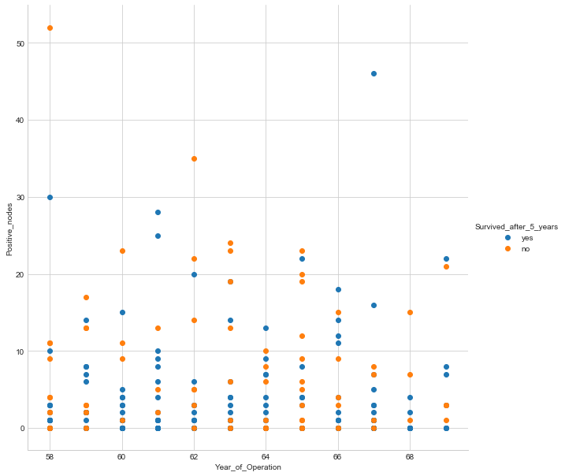

```python
import pandas as pd
import numpy as np
import seaborn as sns
import matplotlib.pyplot as plt

hbdata = pd.read_csv(r"D:\AppliedAI\Homework n Assignments\habermans-survival-data-set\haberman.csv")
hbdata.columns = ["Age","Year_of_Operation","Positive_nodes","Survived_after_5_years"]
hbdata["Survived_after_5_years"] = hbdata["Survived_after_5_years"].map({1:"yes", 2:"no"})

sns.set_style("whitegrid");
sns.FacetGrid(hbdata, hue="Survived_after_5_years", size=8.5) \
   .map(plt.scatter, "Year_of_Operation", "Positive_nodes") \
   .add_legend();
plt.show();
```

# Observations:

- The data is quite scattered and personally i am finding quite difficult to come to any conclusion with help of this

# Scatter Plot Age and Positive nodes (Plot 2)

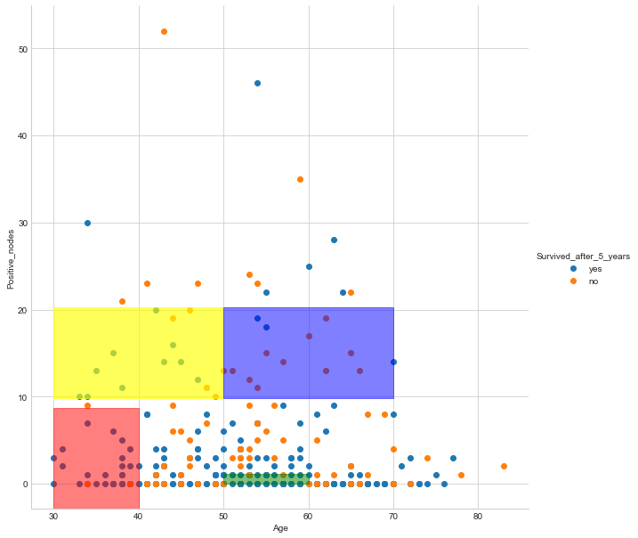

```python
import pandas as pd
import numpy as np
import seaborn as sns
import matplotlib.pyplot as plt

hbdata = pd.read_csv(r"D:\AppliedAI\Homework n Assignments\habermans-survival-data-set\haberman.csv")
hbdata.columns = ["Age","Year_of_Operation","Positive_nodes","Survived_after_5_years"]
hbdata["Survived_after_5_years"] = hbdata["Survived_after_5_years"].map({1:"yes", 2:"no"})

sns.set_style("whitegrid");
sns.FacetGrid(hbdata, hue="Survived_after_5_years", size=8.5) \
   .map(plt.scatter, "Age", "Positive_nodes") \
   .add_legend();
plt.axvspan(xmin=30, xmax=40, ymin=0, ymax=.2, color='red',alpha = .5)
plt.axvspan(xmin=50, xmax=60, ymin=.05, ymax=.07, color='green', alpha= .5)
plt.axvspan(xmin=30, xmax=50, ymin=.22, ymax=.4, color='yellow', alpha= .65)
plt.axvspan(xmin=50, xmax=70, ymin=.22, ymax=.4, color='blue', alpha= .5)

plt.show();
```

# Observations:

1. Difficult to conclude things with surety however in the grid the leftmost and bottomost grid suggest compartively more Blue points compared to yellow, suggesting younger with lesser positive nodes had tendency for surviving much longer(more than 5 years).Check red color rectangle

   There are two more points that but my no means can say that this is some concrete conclusion.Thanks to grid feature i can see at two more places density of blue points is more.
1. The bottomost third grid from left the line with zero positive nodes and age group between 50 to 60 filled with mostly blue line thus we can roughly conclude middle aged between with zero positive nodes lived much longer. Check the green color rectangle
2. Another very faint conclusion is from two grids falling between 10-20 positive nodes and age from 30-50 years there again the frequency of blue dots is more (check yellow rectangle) however the number of data points are fewer or could be there may be lots of data point completely overlapping so we are not able to see but with again can say people within 30-50 year age group with 10-20 positive nodes survived longer at the same time would like to point out i would like to study more through various other plots/graphs to further conclude this point.
3. Also as age is increasing (i.e 50-70 years) and positive nodes also increasing (10-20) the number of yellow dots is increasing and thus people are not living for more than 5 years in such cases. Check the blue rectangle

# Scatter Plot Year of Operation and Age (Plot 3)

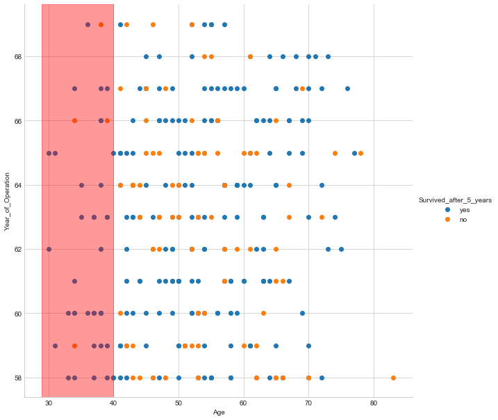

```python
import pandas as pd
import numpy as np
import seaborn as sns
import matplotlib.pyplot as plt

hbdata = pd.read_csv(r"D:\AppliedAI\Homework n Assignments\habermans-survival-data-set\haberman.csv")
hbdata.columns = ["Age","Year_of_Operation","Positive_nodes","Survived_after_5_years"]
hbdata["Survived_after_5_years"] = hbdata["Survived_after_5_years"].map({1:"yes", 2:"no"})
sns.set_style("whitegrid");
sns.FacetGrid(hbdata, hue="Survived_after_5_years", size=8.5) \
   .map(plt.scatter, "Age", "Year_of_Operation") \
   .add_legend();
plt.axvspan (xmin = 29, xmax = 40, color = 'red', alpha = .4 )
plt.show();
```

# Observations:

- Now if we see plot between Age and Year of Operation would like to point out we might be able to make some sense but the amount of lurking variables etc would be so many it would be foolishness to conclude anything but for fun sake lets continue.

##### what we observe:

1) For all the dots between 30-40 age group for all years number of blue dot is more compared to yellow(seems like 20-25 blue and 4-5 yellow). So we observe younger people tend to live longer however we dont know may be younger people having lesser positive nodes and thus living longer or is it even if they are having more positive nodes and still living longer? We have to see other graphs to come to any conclusion.Check red rectangle

2) There might be few more observation but i would say they are very futile and we should not "conclude" anything on the basis of "Age" and "year of operation"

###### #

We had already made all the possible scatter plot 3C2 = 3!/2! x 1! = 3

**# Overall Conclusion based on all the Scatter Plots:**

**1. It is very clear people with lesser positive nodes and lesser age tends to live more**

**2. People with lesser positive nodes irrespective of whatever age also tends to live but would be bit early to make concrete conslusion._**

**3. People with age more than 50+ and positive nodes between range 10-20 tends not to live longer than 5 years.**

[figure not shown]

### Though we have seen all the possible scatter plot but we can also use "pair plot" command to draw all the plots in one shot.

##### Please find the same below

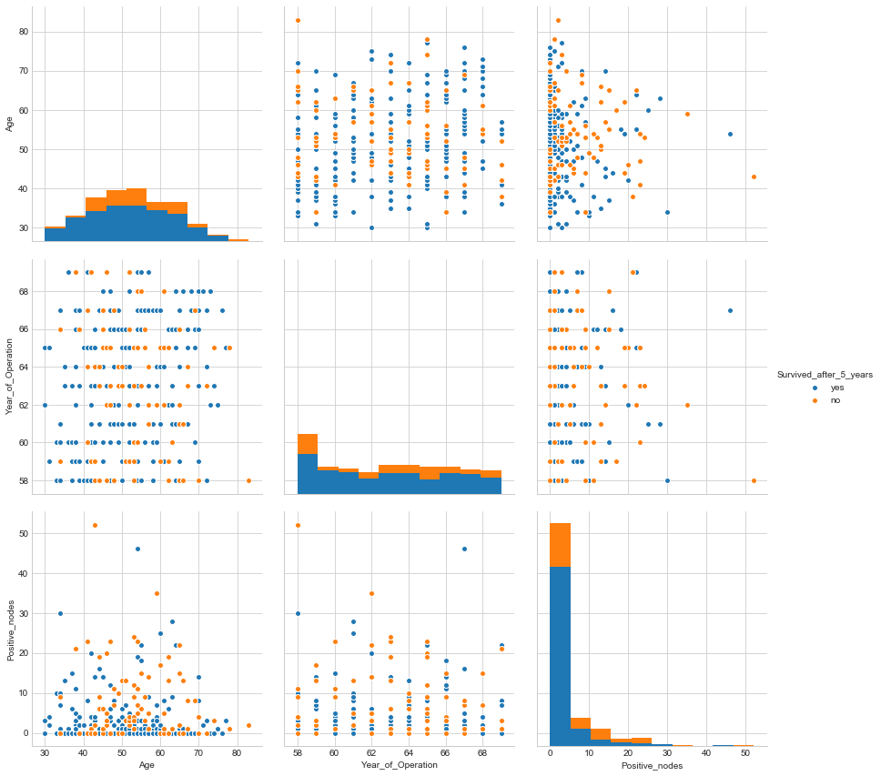

```python
plt.close();
sns.set_style("whitegrid");
sns.pairplot(hbdata, hue="Survived_after_5_years", size=4);

plt.show()
```

# Lets do some 1D analysis

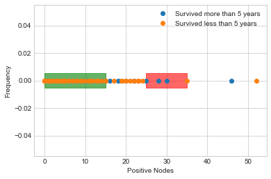

```python
import pandas as pd
import numpy as np
import seaborn as sns
import matplotlib.pyplot as plt

hbdata = pd.read_csv(r"D:\AppliedAI\Homework n Assignments\habermans-survival-data-set\haberman.csv")
hbdata.columns = ["Age","Year_of_Operation","Positive_nodes","Survived_after_5_years"]
hbdata["Survived_after_5_years"] = hbdata["Survived_after_5_years"].map({1:"yes", 2:"no"})
survived_longer = hbdata.loc[hbdata['Survived_after_5_years'] == "yes"]
survived_lesser = hbdata.loc[hbdata['Survived_after_5_years'] == "no"]

plt.plot(survived_longer["Positive_nodes"],np.zeros_like(survived_longer['Positive_nodes']), 'o',\
         label = "Survived more than 5 years")
plt.plot(survived_lesser["Positive_nodes"],np.zeros_like(survived_lesser['Positive_nodes']), 'o', \
         label = "Survived less than 5 years")
plt.xlabel("Positive Nodes")
plt.ylabel("Frequency")
plt.axvspan (xmin = 0, xmax = 15, ymin = .45 , ymax = .55, color = "green", alpha = .6)
plt.axvspan (xmin = 25, xmax = 35, ymin = .45 , ymax = .55, color = "red", alpha = .6)
plt.legend()
plt.show()
```

# Observation:

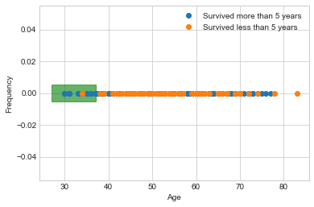

```python
import pandas as pd
import numpy as np
import matplotlib.pyplot as plt
import seaborn as sns

hbdata = pd.read_csv(r"D:\AppliedAI\Homework n Assignments\habermans-survival-data-set\haberman.csv")
hbdata.columns = ["Age","Year_of_Operation","Positive_nodes","Survived_after_5_years"]
hbdata["Survived_after_5_years"] = hbdata["Survived_after_5_years"].map({1:"yes",2:"no"})
survived_longer = hbdata.loc[hbdata['Survived_after_5_years'] == "yes"]
survived_lesser = hbdata.loc[hbdata['Survived_after_5_years'] == "no"]
plt.plot(survived_longer["Age"],np.zeros_like(survived_longer['Age']), 'o', label = "Survived more than 5 years")
plt.plot(survived_lesser["Age"],np.zeros_like(survived_lesser['Age']), 'o', label = "Survived less than 5 years")
plt.xlabel("Age")
plt.ylabel("Frequency")
plt.legend()
plt.axvspan (xmin = 27,xmax = 37, ymin = .45, ymax = .55, alpha = .6, color = "green" )
plt.show()
```

# Observations:

# Lets do histogram for above both graph

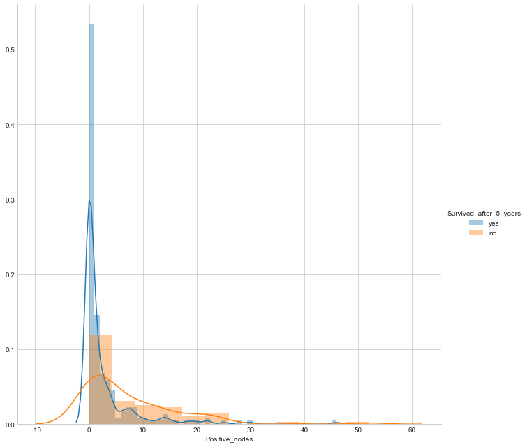

```python
import pandas as pd
import numpy as np
import matplotlib.pyplot as plt
import seaborn as sns
import warnings
warnings.simplefilter("ignore")


hbdata = pd.read_csv(r"D:\AppliedAI\Homework n Assignments\habermans-survival-data-set\haberman.csv")
hbdata.columns = ["Age","Year_of_Operation","Positive_nodes","Survived_after_5_years"]
hbdata["Survived_after_5_years"] = hbdata["Survived_after_5_years"].map({1:"yes",2:"no"})
survived_longer = hbdata.loc[hbdata['Survived_after_5_years'] == "yes"]
survived_lesser = hbdata.loc[hbdata['Survived_after_5_years'] == "no"]
sns.FacetGrid(hbdata,hue = "Survived_after_5_years", size = 9).map(sns.distplot,"Positive_nodes").add_legend();
plt.show();
```